# Analyze output of countingAlleles

### Written by Thuy N. Nguyen on 11/11/19. Edited on 03/09/2020 to include motivations for each part of the analysis and visualization of the data.

**A summary of my data analysis journey:**

- Selection experiment lab notebook reference: TN11p57
- Sample library preparation lab notebook reference: TN11p71-81
- GeneWiz HiSeq run quality control: "191009 genewiz ngs qc". And run summary: "191031_hiseqRun_counts"
- Merged overlapping paired-end reads with USEARCH. See README in 191025_miseqData_genewiz in bioHPC:
- Analyzed these reads with countingAlleles.py
- BioHPC path: "lamella.biohpc.swmededu/project/greencenter/ReynoldsLab/s157382/191025_miseqData_genewiz"

**The goals of this script are:**

1. to evaluate the raw allele counts of each DHFR mutant in the saturation mutagenesis library in both the WT and R166Q TYMS backgrounds.
2. to sanity check fits of growth rate effects for a subset of mutants with known biochemical activities
3. to calculate and fit growth rate for all mutants in this first replicate of the DHFR libraries.

```python
#this defaults plots to matplotlib 1.0 formatting
import matplotlib.style
import matplotlib as mpl
mpl.style.use('classic')
%matplotlib inline
mpl.rcParams['figure.dpi']= 150
```

```python
# import modules you will use
import numpy as np
import scipy.stats as stats
import matplotlib.pyplot as plt
import dist_cols as cols #need distinguishable_colors_python and dist_cols.py in your directory
prettyColors = cols.dist_cols
```

#### How many reads in each sample passed the Quality score 20 filter AND were identified as a DHFR mut or WT allele?

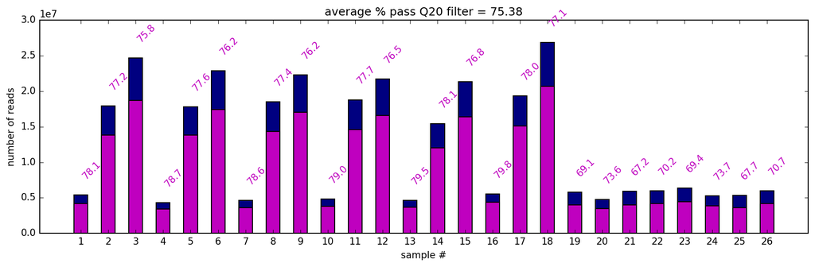

```python
# 1. import raw mutant counts in each sample
path = '/Users/thuynguyen/Desktop/miseqRuns/191110_countingAllelesOutput/'
outname = []
for i in np.arange(1,27):
    outname.append(path+str(i)+'.txt')

# 2.  Determine number of reads that pass the quality score filter and total reads in each sample
total_reads = []
pass_reads = []

for f in outname:
    outfile = open(f,'r').readlines()
    for l in outfile[0:3]:
        sp_l = l.strip().split('\t')
        if sp_l[0] == 'read_total:':
            total_reads.append(float(sp_l[1]))
        if sp_l[0] == 'read_pass:':
            pass_reads.append(float(sp_l[1]))
    open(f,'r').close()

# 3. Visualize percentage of reads in each sample that are high quality

plt.rcParams['figure.figsize'] = 12,4
plt.figure()
x = list(np.arange(1,26*2,2))
plt.bar(x,total_reads,color = 'navy',width = 1)
plt.bar(x,pass_reads,color = 'm',width = 1)

percentPass = list(100*np.array(pass_reads)/np.array(total_reads))
for ix, p in enumerate(percentPass):
    plt.text(x[ix],total_reads[ix]+2.2e6,str(round(p,1)),rotation = 45,color = 'm')
plt.xlim(-2,26*2+2)
plt.xticks(x,np.arange(1,27))
plt.ylabel('number of reads')
plt.xlabel('sample #')
plt.title('average % pass Q20 filter = '+str(round(np.mean(percentPass),2)))
plt.tight_layout()

# 4. Save pdf version of figure to disk and for lab notebook
plt.savefig('figs_pass qscore filter.pdf',fmt='pdf')
```

```python
print('An average of %i percent reads pass the quality score filter in each sample. ' %\
float(round(100*np.mean(pass_reads)/np.mean(total_reads),2)))
```

```
An average of 76 percent reads pass the quality score filter in each sample.
```

```python
# What is in each sample?
# How are you going to organize mutant counts in each sample?

#initialize with information about the experiment
time = [-24,0,4,8,12,20,24] #time point
timeName = ['untransformed','t0','t4','t8','t12','t20','t24']
sublibraries = ['sl1','sl2','sl3','sl4']
tyms = ['wt','r166q']

#presence filter!
count_threshold = 100

sampleInfo = { #for each sample number what sub-library, timepoint, and TYMS background does it correspond to?
    '1': 'sl1_t0_wt',
    '2': 'sl2,sl3,sl4_t0_wt', #you have to specify sub-set of sub-libraries or code will overwrite SL1_t0 counts
    '3': 'mix_t0_r166q', #mix means all 4 sub-libraries are intentionally mixed there
    '4': 'sl1_t4_wt',
    '5': 'sl2,sl3,sl4_t4_wt',
    '6': 'mix_t4_r166q',
    '7': 'sl1_t8_wt',
    '8': 'sl2,sl3,sl4_t8_wt',
    '9':  'mix_t8_r166q',
    '10': 'sl1_t12_wt',
    '11': 'sl2,sl3,sl4_t12_wt',
    '12': 'mix_t12_r166q',
    '13': 'sl1_t20_wt',
    '14': 'sl2,sl3,sl4_t20_wt',
    '15':  'mix_t20_r166q',
    '16': 'sl1_t24_wt',
    '17': 'sl2,sl3,sl4_t24_wt',
    '18': 'mix_t24_r166q',
    '19':  'sl1_untransformed_wt',
    '20': 'sl2_untransformed_wt',
    '21': 'sl3_untransformed_wt',
    '22': 'sl4_untransformed_wt',
    '23': 'sl1_untransformed_r166q',
    '24': 'sl2_untransformed_r166q',
    '25': 'sl3_untransformed_r166q',
    '26': 'sl4_untransformed_r166q'
}


# all possible amino acids mutants in DHFR
AA = 'ACDEFGHIKLMNPQRSTVWY*'
wt_aa_sequence= {}
wt_aa_sequence['sl1']= 'MISLIAALAVDRVIGMENAMPWNLPADLAWFKRNTLNKPV'
wt_aa_sequence['sl2']= 'IMGRHTWESIGRPLPGRKNIILSSQPGTDDRVTWVKSVDE'
wt_aa_sequence['sl3']= 'AIAACGDVPEIMVIGGGRVYEQFLPKAQKLYLTHIDAEVE'
wt_aa_sequence['sl4']= 'GDTHFPDYEPDDWESVFSEFHDADAQNSHSYCFEILERR*'

aa_pos = {} #python index of amino acid position in DHFR
aa_pos['sl1'] = np.arange(1,40+1)
aa_pos['sl2'] = np.arange(41,80+1)
aa_pos['sl3'] = np.arange(81,120+1)
aa_pos['sl4'] = np.arange(121,160+1)

# each sub-library gets a list of all possible amino acid mutations
mutants_lists = {}
for sl_id in sublibraries:
    mutants_lists[sl_id] = []
    mutants_lists[sl_id].append('WT')

    wtseq = wt_aa_sequence[sl_id]
    for posix,pos in enumerate(aa_pos[sl_id]):
        wt = wtseq[posix]+str(pos)
        for a in AA:
            mutants_lists[sl_id].append(wt+a)
```

### Organizing and storing data in two forms:

1. a matrix of DHFR sequence vs amino acids for each sub-library, timepoint, and tyms background. This is to easily do matrix based math and visualization of heat maps.
2. a dictionary of mutant (key) and mutant count (values) to keep track of names of mutants associated with each mutant count.

NOTE: This is not ideal. You should try to later edit this code so that you are not so restricted to using two separate data types in your analysis of allele counts.

```python
countRaw_mut_mat = np.zeros(shape = (len(sublibraries),len(time),len(tyms),len(wt_aa_sequence['sl1']),len(AA)))
countRaw_WT_mat = np.zeros(shape = (len(sublibraries),len(time),len(tyms)))
countRaw_dict = {}

countPresent_mut_mat = np.zeros(shape = (len(sublibraries),len(time),len(tyms),len(wt_aa_sequence['sl1']),len(AA)))
countPresent_WT_mat =  np.zeros(shape = (len(sublibraries),len(time),len(tyms)))
countPresent_dict = {}

fitness_mut_mat = np.ones(shape = (len(sublibraries),len(tyms),len(wt_aa_sequence['sl1']),len(AA)))
fitness_dict = {}

for s in sublibraries:
    fitness_dict[s] = {}
    countPresent_dict[s] = {}
    countRaw_dict[s] = {}
    for t in tyms:
        fitness_dict[s][t] = {}
        countPresent_dict[s][t] = {}
        countRaw_dict[s][t] ={}
        for tp in timeName:
            fitness_dict[s][t][tp] = []
            countPresent_dict[s][t][tp] = []
            countRaw_dict[s][t][tp] = []

def fill_data():
    if mutID in mutants_lists[sl_id]: #fill dictionaries
        #count_threshold = round(mutCount/100)
        countRaw_dict[sl_id][tymsID][tp].append(mutCount)
        if mutCount >= count_threshold:
            countPresent_dict[sl_id][tymsID][tp].append(mutCount)
        else:
            countPresent_dict[sl_id][tymsID][tp].append(1) #set to 1 so that absent mutants are log10(1) == 0.

        if mutID == 'WT':  #now fill matricies
            countRaw_WT_mat[sublib_ix,tp_ix,ts_ix] = mutCount
            if mutCount >= count_threshold:
                countPresent_WT_mat[sublib_ix,tp_ix,ts_ix] = mutCount#- count_threshold
        else:
            mut_ix = list(aa_pos[sl_id]).index(int(mutID[1:-1]))
            aa_ix = AA.index(mutID[-1])
            countRaw_mut_mat[sublib_ix,tp_ix,ts_ix,mut_ix,aa_ix] = mutCount
            if mutCount >= count_threshold:
                countPresent_mut_mat[sublib_ix,tp_ix,ts_ix,mut_ix,aa_ix] = mutCount #- count_threshold

for f in outname:
    countsFile = open(f,'r')
    countsFileRead = countsFile.readlines()

    samp_id = f.strip().split('/')[-1].strip('.txt') #this is specific to the format of your output file names

    sampleSL, tp, tymsID = sampleInfo[samp_id].split('_') #sub-library ID, timepoint, or tymsID

    tp_ix = timeName.index(tp)
    ts_ix = tyms.index(tymsID)
    #print tp,tymsID

    #account for samples with mixed sub-libraries
    sampleSL_list = list(sampleSL.split(','))
    if sampleSL_list == ['mix']:
        sampleSL_list = ['sl1','sl2','sl3','sl4']

    for l in countsFileRead[6:]: #only pulling out information after stats like total read counts and failed read counts
        sp_l = l.strip().split('\t')

        mutID = sp_l[1]
        mutCount = float(sp_l[2])

        sl_id = sp_l[0] #this mutant has this sub-library associated with it
        if sl_id in sampleSL_list: #check to see if you expected to see it in the sample you prepared
            sublib_ix = sublibraries.index(sl_id)
            fill_data()

    countsFile.close()
```

### Before continuing with further data analysis, check counts for each mutant and each sample with heatmaps.

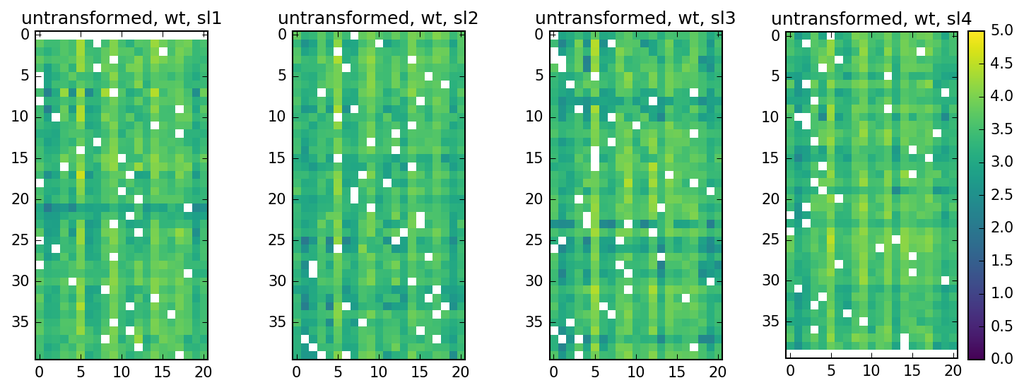

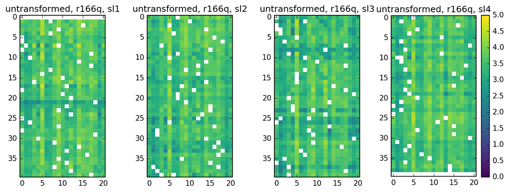

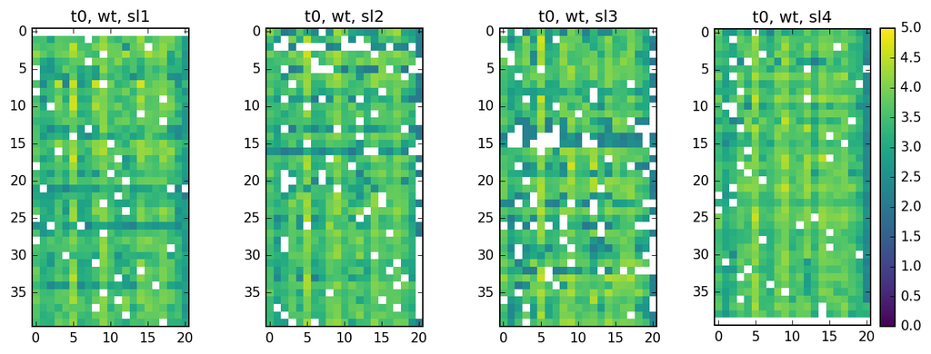

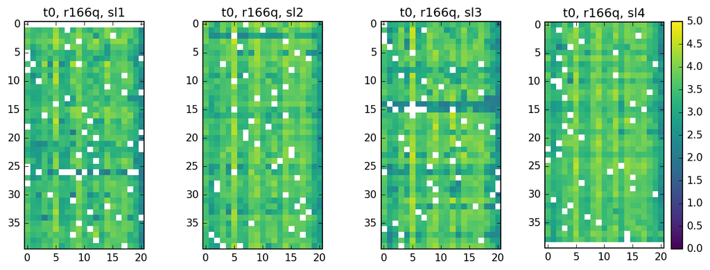

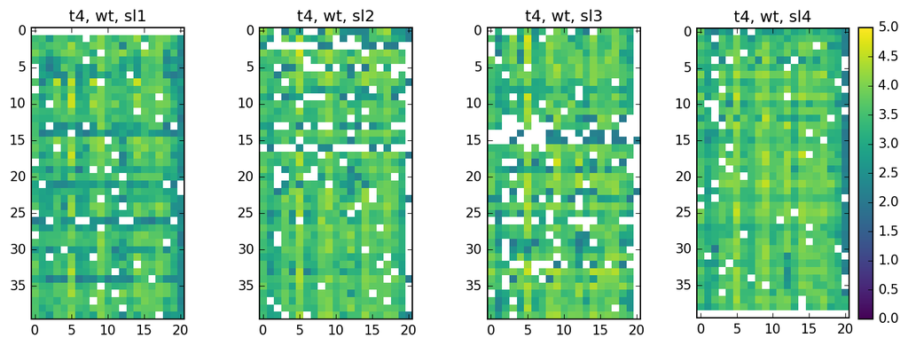

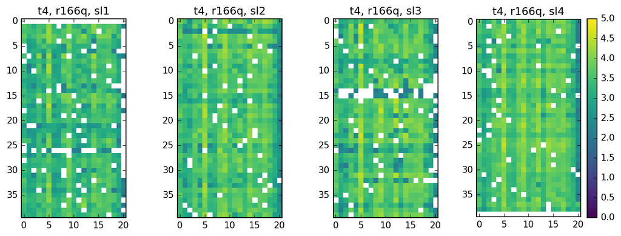

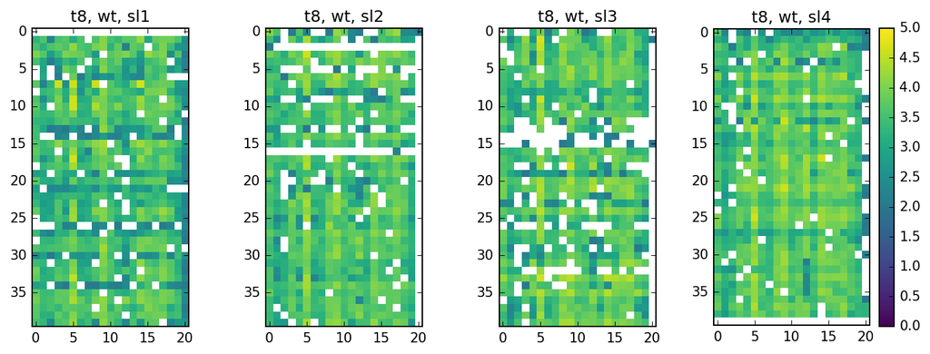

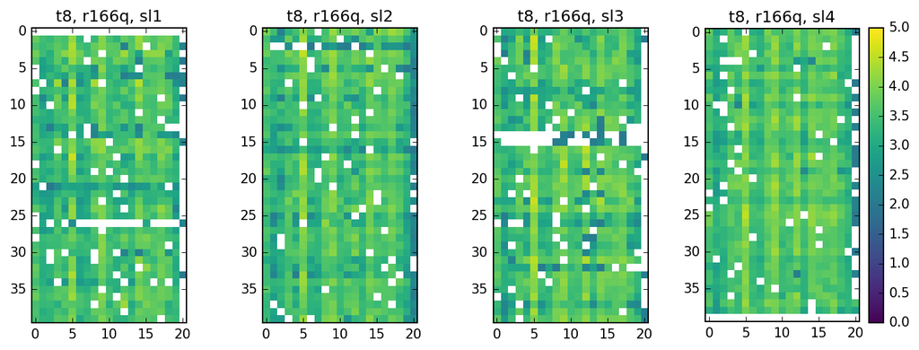

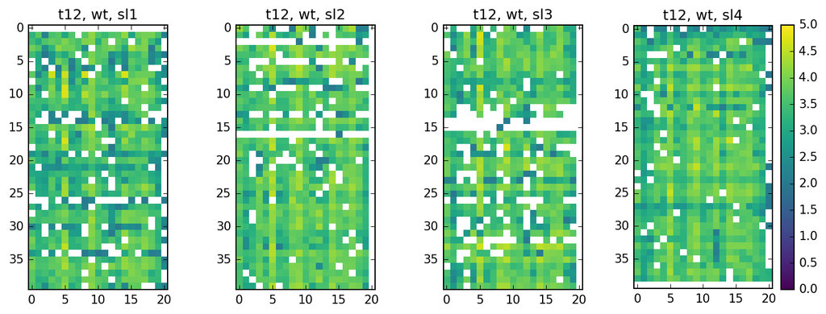

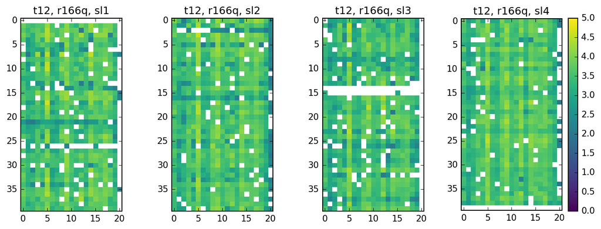

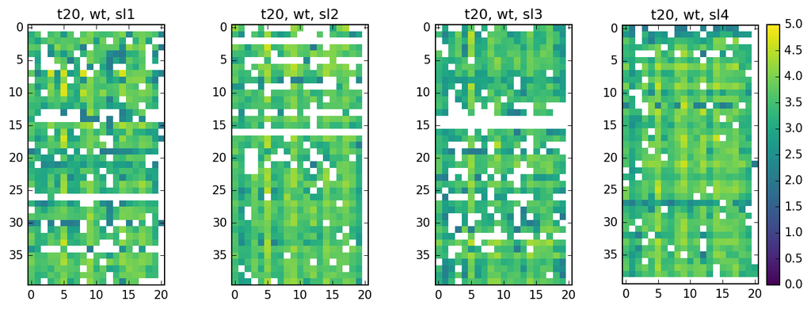

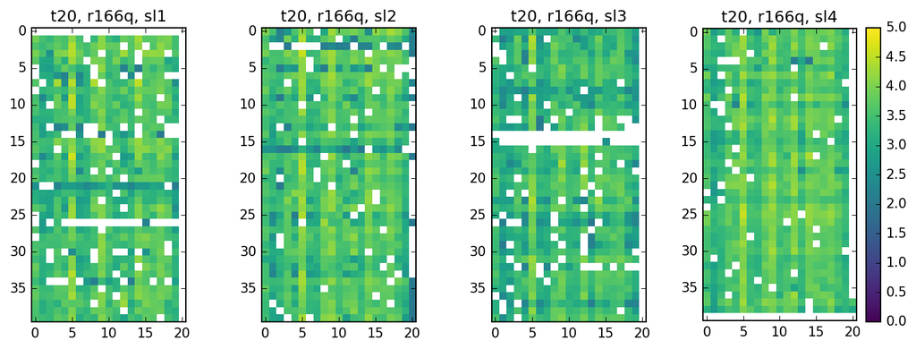

[2 more figures not shown]

```python
plt.rcParams['figure.figsize'] = 12,4
for t in range(len(timeName)):
    for ts in range(len(tyms)):
        plt.figure()
        for i in range(len(sublibraries)):
            plt.subplot(1,4,i+1)
            plt.title(timeName[t]+', '+ tyms[ts]+ ', '+sublibraries[i])
            plt.imshow(np.log10(countPresent_mut_mat[i,t,ts,:,:]),vmin = 0, vmax = 5, cmap = 'viridis',interpolation = 'nearest')
        plt.colorbar()
```

Since most mutants appear to be present, what are the average reads/mutant in each sample?

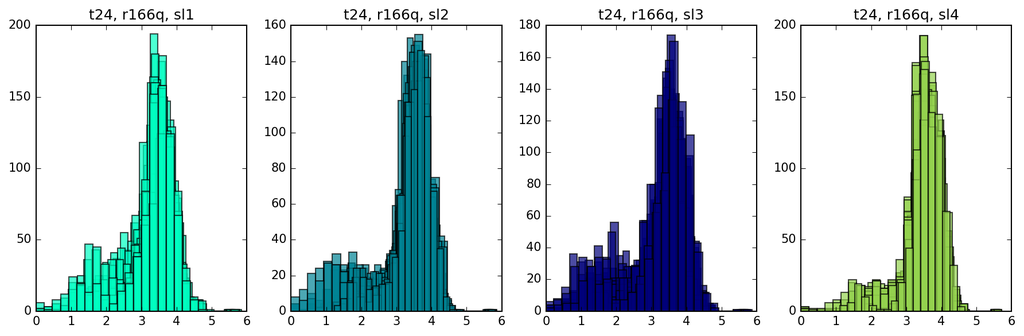

```python
plt.rcParams['figure.figsize'] = 12,4

for t in range(len(timeName)):
    for ts in range(len(tyms)):
        #plt.figure()
        for i in range(len(sublibraries)):
            plt.subplot(1,4,i+1)
            plt.title(timeName[t]+', '+ tyms[ts]+ ', '+sublibraries[i])
            plt.hist(np.log10(countRaw_dict[sublibraries[i]][tyms[ts]][timeName[t]]),bins = 25,color = prettyColors[i+9,:],alpha = 0.7)
        plt.ylim(0,200)
        plt.xlim(0,6)
        plt.tight_layout()
```

```
sl1 wt 5195.0 15714.0
sl2 wt 4792.0 18414.0
sl3 wt 5393.0 19363.0
sl4 wt 5718.0 16911.0
sl1 r166q 4675.0 22626.0
sl2 r166q 5794.0 21325.0
sl3 r166q 5730.0 22199.0
sl4 r166q 5572.0 17241.0
```

```
[-1, 5, -1, 5]
```

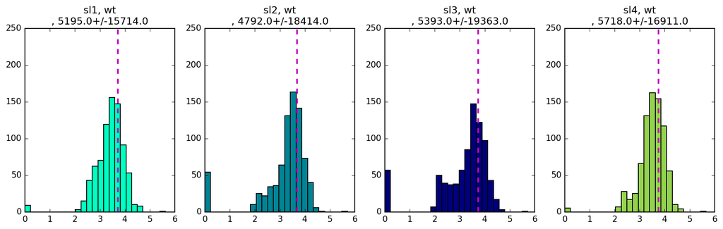

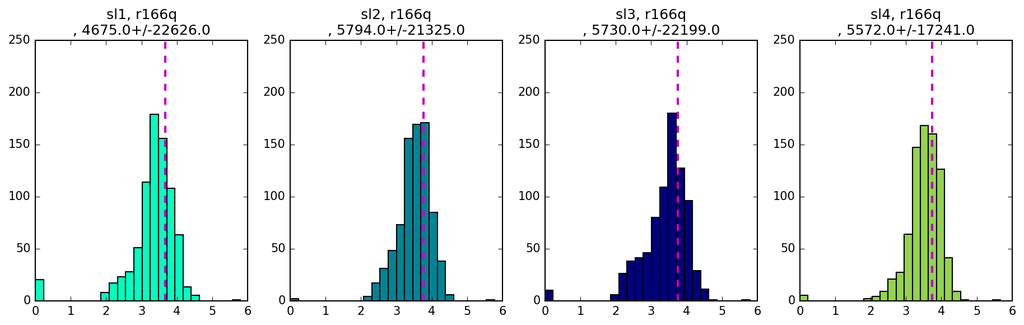

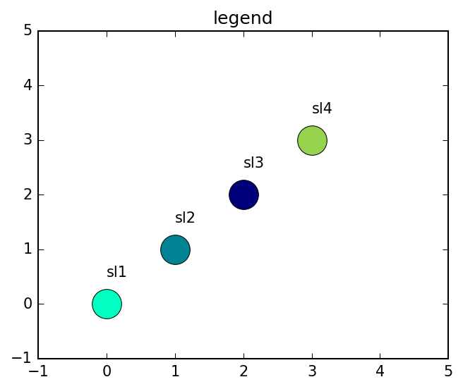

```python
plt.rcParams['figure.figsize'] = 15,4
tp = 't0'
for ts in range(len(tyms)):
    plt.figure()
    plt.title(tyms[ts])
    for i in range(len(sublibraries)):
        plt.subplot(1,4,i+1)
        mean = round(np.mean(countPresent_dict[sublibraries[i]][tyms[ts]][tp]))
        stdev = round(np.std(countPresent_dict[sublibraries[i]][tyms[ts]][tp]))
        plt.title(sublibraries[i]+', '+ tyms[ts]+'\n'
                 ', '+ str(mean)+'+/-'+str(stdev))

        print(sublibraries[i], tyms[ts], mean, stdev)
        plt.hist(np.log10(countPresent_dict[sublibraries[i]][tyms[ts]][tp]),bins = 25,color = prettyColors[i+9,:])#,alpha = 0.7)
        plt.ylim(0,250)
        plt.xlim(0,6)

        mean = np.log10(mean)
        plt.plot([mean,mean],[0,1000],'--',color ='m',linewidth = 2)

    #plt.tight_layout()


plt.rcParams['figure.figsize'] = 5,4
plt.figure()
plt.title('legend')
for i in range(len(sublibraries)):
    plt.plot(i,i,'o',color = prettyColors[i+9,:],markersize=20)
    plt.text(i,i+0.5,sublibraries[i])
plt.axis([-1,5,-1,5])
```

Mutant counts in plasmid libraries are >> 1000x. Now check to see if there is a difference in mutant coverage between the two TYMS backgrounds.

```
WT TYMS avg reads/mutant 5272.0
R166Q TYMS avg reads/mutant 5446.0
```

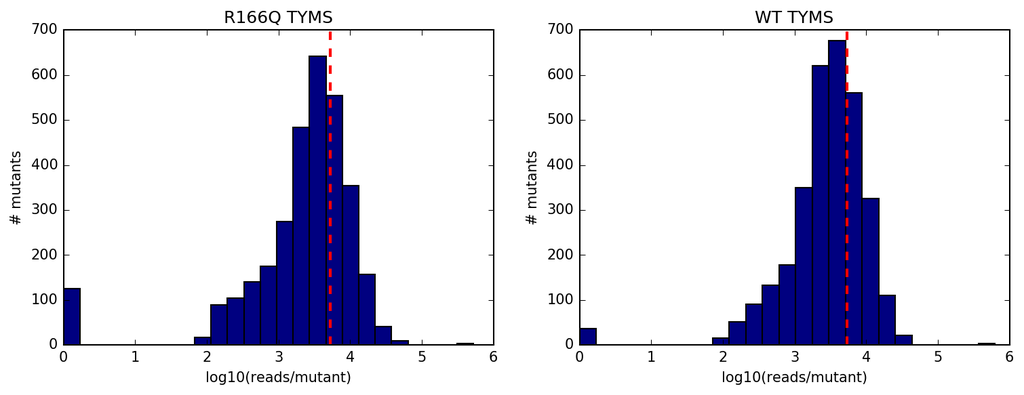

```python
histwt = []
histr166q = []
for slix, sl in enumerate(sublibraries):
    for i in countPresent_dict[sl]['wt']['t0']:
        histwt.append(i)
    for i in countPresent_dict[sl]['r166q']['t0']:
        histr166q.append(i)
plt.rcParams['figure.figsize'] = 12,4
plt.figure()
plt.subplot(1,2,1)
plt.hist(np.log10(histwt),color = 'navy',bins = 25)
avg = np.log10(np.mean(histwt))
plt.plot([avg,avg],[0,700],'r--',linewidth = 2)
print('WT TYMS avg reads/mutant',round(np.mean(histwt)))

plt.title('R166Q TYMS')
plt.xlabel('log10(reads/mutant)')
plt.ylabel('# mutants')
plt.subplot(1,2,2)
plt.hist(np.log10(histr166q),color = 'navy',bins = 25)
avg = np.log10(np.mean(histr166q))
print('R166Q TYMS avg reads/mutant',round(np.mean(histr166q)))

plt.plot([avg,avg],[0,700],'r--',linewidth = 2)
plt.title('WT TYMS')
plt.xlabel('log10(reads/mutant)')
plt.ylabel('# mutants')
```

```python
def plot_heatmap(matrix,dhfr_wt_seq,MIN = 0,MAX = 5,colormap='viridis'):
    ##plots a heatmap of log10(matrix)
    ##matrix - the data
    ##color map default is viridis, you can change it to whatever you want
    ##x and y ticks spacing defaults to len of x and y axes of matrix
    ##x and y tick labels default to the indicies of x and y axes of the matrix. change it if you want to..

    plt.rcParams['figure.figsize'] = 10,20

    yticks=np.arange(len(matrix[:,0]))
    ylabel = dhfr_wt_seq#np.arange(len(matrix[:,0]))

    xticks = np.arange(len(matrix[0,:]))
    xlabel= AA#np.arange(len(matrix[0,:]))

    plt.imshow(np.log10(matrix), cmap = colormap, vmin = MIN, vmax = MAX,interpolation = 'nearest')

    plt.colorbar(shrink = 0.3, orientation = 'vertical', pad = 0.01)
    plt.xticks(xticks+0.5,xlabel)
    plt.yticks(yticks+0.5,ylabel)
    plt.grid(color = 'k',linestyle = '-',linewidth = 2)
```

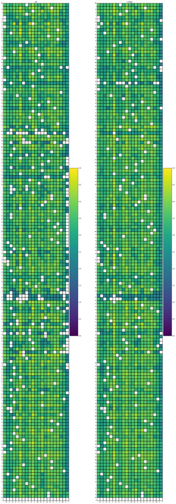

```python
full_dhfr_aaSeq = wt_aa_sequence['sl1']+wt_aa_sequence['sl2']+wt_aa_sequence['sl3']+wt_aa_sequence['sl4']
plt.rcParams['figure.figsize'] = 20,65
tp = timeName.index('t0')
plt.figure()
for tsix,ts in enumerate(tyms):
    plt.subplot(1,2,tsix+1)
    full_mat = np.concatenate([countPresent_mut_mat[slid,tp,tsix,:,:] for slid in range(len(sublibraries))])
    plot_heatmap(full_mat,full_dhfr_aaSeq)
    plt.title(ts)
```

### What are the growth rate effects of DHFR mutants with known catalytic activities?

```python
def filterCounts(mutCounts, time = [0,4,8,12,20,24]):
    tp2fit = [0]
    counts2fit =[0]
    mutCounts = np.array(mutCounts)
    ixnonzeros = np.array(mutCounts) != 0 #step 2 determine where present timepoints are
    if len(mutCounts[ixnonzeros]) >= 3:
        t = np.array(time)
        tp2fit = t[ixnonzeros]
        counts2fit = mutCounts[ixnonzeros]
        if mutCounts[-1] == 0:
            counts2fit = np.append(mutCounts[ixnonzeros],1) #replace zero with one
            tp2fit = np.append(tp2fit, t[-1])
    return tp2fit, counts2fit

def relFreqFunc(mutCounts, WTcounts):
    tp2fit, counts2fit = filterCounts(mutCounts)


    #if not present at the beginning of the experiment, continue
    if 0 not in list(tp2fit):
        relFreq = []
        tp2fit = [] #retrun a blank list if not present at the beginning of the experiment

    if 0 in list(tp2fit):
        relFreq = []
        for tpix, tp in enumerate(tp2fit):
            wt = WTcounts[tpix]
            wt0 = WTcounts[list(tp2fit).index(0)]
            mut = counts2fit[tpix]
            mut0 = counts2fit[list(tp2fit).index(0)]
            relFreq.append(np.log2(mut/wt)-np.log2(mut0/wt0))

    return tp2fit, relFreq
```

Import DHFR catalytic activities and define mini-library/calibration curve library

```python
cl_mutants = ['WT','M42F','L54I','W22H','D27N','L28F','L28Y','F31V','F31Y','G121V','T113V']

path = '/Users/thuynguyen/Documents/ReynoldsLab/fitness_DHFR_pACYC/kinetics_dhfr.txt'
kin_data = open(path,'rU').readlines()
dhfr = []
kcat = []
km = []

for line in kin_data[1:]:
    data = line.split('\t')
    dhfr.append(data[0])
    kcat.append(float(data[1]))
    km.append(float(data[2].strip()))

#these kinetic data are measured and reported in Reynolds, 2011, Cell.
#L28F, L28Y, T113V are not here. Take these kinetic values from the literature
l28f_kin_data = ['L28F','50','1'] #wagner, 1992, Biochemistry
l28y_kin_data = ['L28Y','15','1'] #huang, 1994, Biochemistry
t113v_kin_data = ['T113V','24.60','1.75'] #Tien, 2015, PLOS CompBio
dhfr.append(l28f_kin_data[0])
dhfr.append(l28y_kin_data[0])
dhfr.append(t113v_kin_data[0])
kcat.append(float(l28f_kin_data[1]))
kcat.append(float(l28y_kin_data[1]))
kcat.append(float(t113v_kin_data[1]))
km.append(float(l28f_kin_data[2]))
km.append(float(l28y_kin_data[2]))
km.append(float(t113v_kin_data[2]))

#also from Reynolds, 2011, Cell. Not in csv file of dhfr kinetics
f31y_kin_data = ['F31Y','20.61', '80']
dhfr.append(f31y_kin_data[0])
kcat.append(float(f31y_kin_data[1]))
km.append(float(f31y_kin_data[2]))

dhfr_kinetics = {'dhfr':dhfr, 'kcat':kcat, 'km':km}
print(dhfr_kinetics)

#pull out biochemical parameters that you care about in this experiment
dhfr_expt = []
for m in cl_mutants:
    if m == 'F31Y.L54I':
        m = 'F31YL54I'
    if m == 'other':
        continue
    dhfr_expt.append(m.upper())

kcat_expt = []
km_expt = []
cat_eff_expt = []
#velocity = []
velocity = {}
dhf = 10 #conc of substrate in microM
for dhfr in dhfr_expt:

    ix = dhfr_kinetics['dhfr'].index(dhfr)

    kcat_temp =float(dhfr_kinetics['kcat'][ix])
    km_temp = float(dhfr_kinetics['km'][ix])

    kcat_expt.append(kcat_temp)
    km_expt.append(km_temp)

    cat_eff_expt.append(np.divide(kcat_temp,km_temp))
    velocity_tmp = np.divide(kcat_temp*dhf,km_temp+dhf)
    velocity[dhfr.lower()] = velocity_tmp

cat_eff_expt_log = np.log10(cat_eff_expt)

print('the catalytic activities in cat_eff_expt_log are indexed by dhfr in dhfr_expt')
print(dhfr_expt)
print(cat_eff_expt_log)
```

```
{'dhfr': ['WT', 'M42F', 'L54I', 'W22H', 'F31V', 'G121V', 'F31YL54I', 'M42FG121V', 'F31YG121V', 'D27N', 'L28F', 'L28Y', 'T113V', 'F31Y'], 'kcat': [7.95, 79.2, 7.88, 1.89, 8.65, 0.3, 1.94, 0.4, 0.13, 0.05, 50.0, 15.0, 24.6, 20.61], 'km': [1.1, 13.0, 35.0, 18.0, 108.0, 6.1, 168.3, 71.8, 90.6, 330.0, 1.…
the catalytic activities in cat_eff_expt_log are indexed by dhfr in dhfr_expt
['WT', 'M42F', 'L54I', 'W22H', 'D27N', 'L28F', 'L28Y', 'F31V', 'F31Y', 'G121V', 'T113V']
[ 0.85897444  0.78478183 -0.64754183 -0.9788107  -3.81954394  1.69897
  1.17609126 -1.09640765 -0.589012   -1.30820858  1.14789706]
```

Pulling out data from only mutants in control library, calculate allelic frequency relative to wild-type, and then fitting linear regression of frequency vs time to calculate a slope. This slope is the effect of a mutant on bacterial growth rate.

```
[-2, 13, -2, 13]
```

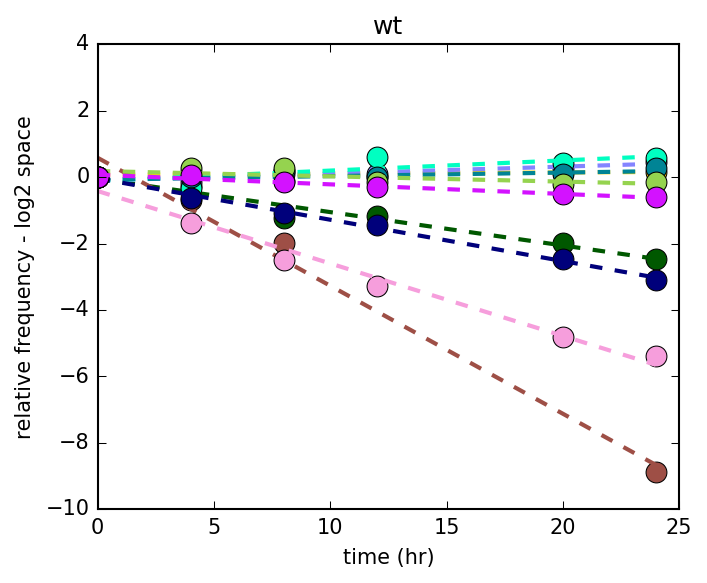

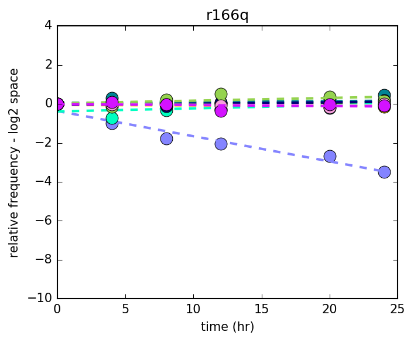

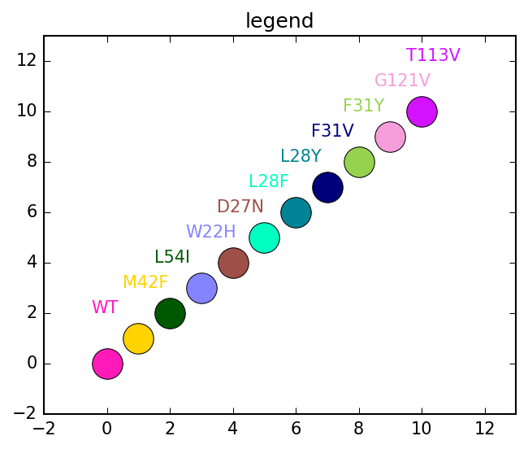

```python
cl_mutants = ['WT','M42F','L54I','W22H','D27N','L28F','L28Y','F31V','F31Y','G121V','T113V']
countPresent_cl_mat = np.zeros(shape = (len(cl_mutants),len(timeName),len(tyms)))
relFreq_cl_mat = np.zeros(shape = (len(cl_mutants),len(timeName),len(tyms)))
fitness_cl_mat = np.zeros(shape = (len(cl_mutants),len(tyms)))
for mutix, mut in enumerate(cl_mutants):
    if mut == 'WT':
        continue
    mutPos_aa = AA.index(mut[-1])
    for sl_ix, s in enumerate(sublibraries):
        dhfrN = int(mut[1:-1])
        if dhfrN in list(aa_pos[s]):
            mutPos_dhfr = list(aa_pos[s]).index(dhfrN)

            # save un-normalized counts to matrix
            for tpix, tp in enumerate(timeName):
                for tsix, ts in enumerate(tyms):
                    countPresent_cl_mat[mutix,tpix,tsix] = \
                    countPresent_mut_mat[sl_ix,tpix,tsix,mutPos_dhfr,mutPos_aa]


#calculate relative frequencies
plt.rcParams['figure.figsize'] = 5,4
for tsix,ts in enumerate(tyms):
    plt.figure()
    plt.title(ts)
    plt.xlabel('time (hr)')
    plt.ylabel('relative frequency - log2 space')
    plt.ylim(-10,4)
    #print(ts.upper())
    col = 4
    for mutix, mut in enumerate(cl_mutants):
        if mut == 'WT':
            plt.plot(time[1:], relFreq_cl_mat[0,1:,tsix],'o',color = prettyColors[4,:])
            col+=1
            continue
        mutPos_aa = AA.index(mut[-1])
        for sl_ix, s in enumerate(sublibraries):
            dhfrN = int(mut[1:-1])
            if dhfrN in list(aa_pos[s]):
                mutPos_dhfr = list(aa_pos[s]).index(dhfrN)
                mutMat = countPresent_cl_mat[mutix,1:,tsix]
                wtMat = countPresent_WT_mat[sl_ix,1:,tsix]
                tp2fit, relFreq = relFreqFunc(mutMat,wtMat)
                for tp in tp2fit:
                    relFreq_cl_mat[mutix,time.index(tp),tsix] = relFreq[list(tp2fit).index(tp)]
                plt.plot(tp2fit,relFreq,'ko',color = prettyColors[col,:],markersize = 10)

                slope, intercept, r_value, p_value, std_err = stats.linregress(tp2fit,relFreq)
                fitness_cl_mat[mutix,tsix] = slope

                rsquared = r_value**2

                #print(mut, 'fitness',round(slope,2), 'rsq',round(rsquared,2))

                if np.isnan(slope):
                    col+=1
                    continue
                else:
                    y = slope*tp2fit + intercept
                    plt.plot(tp2fit,y,'--',color = prettyColors[col,:],linewidth = 2)
                    col+=1
plt.figure()
plt.title('legend')
col = 4
for mix, mut in enumerate(cl_mutants):
    plt.plot(mix,mix,'o',markersize=18,color = prettyColors[col,:])
    plt.text(mix-0.5,mix+2,mut,color = prettyColors[col,:])
    col += 1
plt.axis([-2,len(cl_mutants)+2,-2,len(cl_mutants)+2])
```

Linear regression of relative allelic frequency over time for these mutants are great.

### Now, how do their growth rates compare to biochemical activity? Is this consistent with trend in prior measuremnets of growth for these same mutants?

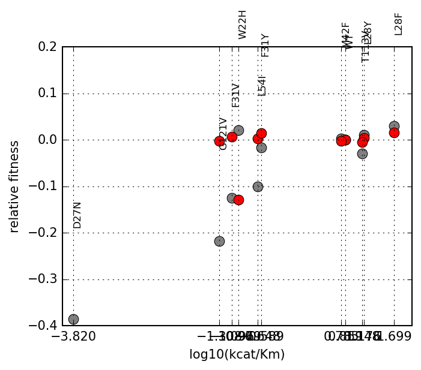

```python
plt.rcParams['figure.figsize'] = 5,4

plt.figure()
plt.plot(cat_eff_expt_log,fitness_cl_mat[:,0],'o',color = 'grey',markersize=8)
plt.plot(cat_eff_expt_log,fitness_cl_mat[:,1],'ro',markersize=8)
for i in range(len(cl_mutants)):
    plt.text(cat_eff_expt_log[i],fitness_cl_mat[i,0]+0.2,cl_mutants[i],rotation = 90,fontsize=8)
plt.ylim(-0.4,0.2)
plt.xlim(-4,2)
plt.xlabel('log10(kcat/Km)')
plt.ylabel('relative fitness')
plt.xticks(cat_eff_expt_log)
plt.grid()
```

Checking if mutant counts filled in matricies match counts in .txt files

```python
def mutLookUp(mut,sl): # returns ix for looking up desired mutant in matrix
    aaIX = AA.index(mut[-1])
    posIX = list(aa_pos[sl]).index(int(mut[1:-1]))
    return posIX,aaIX

mutCheckList = ['D27N','F31V','M42F','T113V','G121V']
for m in mutCheckList:
    for sl in sublibraries:
        if m in mutants_lists[sl]:
            p,a = mutLookUp(m,sl)
            print (m, countRaw_mut_mat[sublibraries.index(sl),:,0,p,a])
```

```
D27N [2259.  438.  244.  108.   68.   45.   37.]
F31V [9453. 7799. 4493. 3614. 3120. 1553. 1256.]
M42F [1102. 1162. 1392. 1310. 1653. 1439. 1759.]
T113V [4841. 4986. 5272. 4802. 4289. 2337. 4036.]
G121V [8794. 6484. 2371. 1231.  649.  224.  156.]
```

How do these fitness measurements compare to ones in miseq run on 190821? To published measurements in Schober et al.?

```python
# import fits and save to matrix
#importing fitness measurements made in miseq on 190821
cl_190821_mut = [[],[]]
cl_190821_fit = [[],[]]
cl_190821_rsq = [[],[]]


cl_190821_file = open('/Users/thuynguyen/Desktop/miseqRuns/190821_miseq/190821_miseqDHFRfitness_CLDHFR.txt','r')
for l in cl_190821_file.readlines()[1:]:
    dr, ts, fitness, rsquared = l.strip().split('\t')
    tsix = tyms.index(ts.lower())
    cl_190821_mut[tsix].append(dr)
    cl_190821_fit[tsix].append(float(fitness))
    cl_190821_rsq[tsix].append(float(rsquared))

mutCL190821_ix = [dhfr_kinetics['dhfr'].index(m) for m in cl_190821_mut[0]]
cl_190821_fit = np.array(cl_190821_fit)
```

```python
#importing fitness measured by Chris in Schober et al.
#the relevant mutant subset
mutsASexpt = ['WT','M42F','L54I','W22H','F31V','G121V', 'F31YL54I', 'M42FG121V', \
              'F31YG121V', 'D27N']
mutAsIx = [dhfr_kinetics['dhfr'].index(m) for m in mutsASexpt]

#gr data
ASrelGR50thy =[[0,-0.0041,-0.0000,-0.0017,-0.0072,-0.0059,-0.0303,-0.0677,-0.0986,-0.1169],
[0.0044, 0.0057, 0.0023, 0.0082, 0.0031, 0.0012, -0.0077,-0.0016,-0.0119, -0.0838]]
ASrelGR50thy = np.array(ASrelGR50thy)

# converting to log2 relative growth rates for comparison to doubling time
# based growth rate calcs...
ASrelGR50thyB2 = ASrelGR50thy/np.log10(2)
```

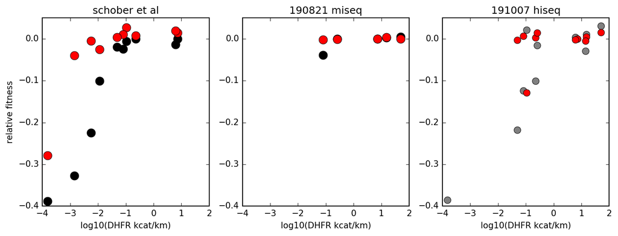

```python
#plot DHFR activity vs fitness for schober's data
plt.rcParams['figure.figsize'] = 12,4
plt.figure()
plt.subplot(1,3,1)
for mAix, m in enumerate(mutsASexpt):
    mix = mutAsIx[mAix]
    x = np.log10(dhfr_kinetics['kcat'][mix]/dhfr_kinetics['km'][mix])
    y_wt = ASrelGR50thyB2[0][mAix]
    y_r166q = ASrelGR50thyB2[1][mAix]
    plt.plot(x,y_wt,'ko',markersize=10)
    plt.plot(x,y_r166q,'ro',markersize=10)

plt.title('schober et al')
plt.xlim(-4,2)
plt.ylim(-0.4,0.05)
plt.xlabel('log10(DHFR kcat/km)')
plt.ylabel('relative fitness')

#same for your 190821 miseq data
plt.subplot(1,3,2)
plt.title('190821 miseq')
for mTix, m in enumerate(cl_190821_mut[0]):
    mix = mutCL190821_ix[mTix]
    x = np.log10(dhfr_kinetics['kcat'][mix]/dhfr_kinetics['km'][mix])
    y_wt = cl_190821_fit[0][mTix]
    y_r166q = cl_190821_fit[1][mTix]
    plt.plot(x,y_wt,'ko',markersize=10)
    plt.plot(x,y_r166q,'ro',markersize=10)

plt.xlim(-4,2)
plt.ylim(-0.4,0.05)
plt.xlabel('log10(DHFR kcat/km)')

plt.subplot(1,3,3)
plt.plot(cat_eff_expt_log,fitness_cl_mat[:,0],'o',color = 'grey',markersize=8)
plt.plot(cat_eff_expt_log,fitness_cl_mat[:,1],'ro',markersize=8)
plt.title('191007 hiseq')
plt.xlabel('log10(DHFR kcat/km)')
plt.xlim(-4,2)
plt.ylim(-0.4,0.05)



plt.rcParams['figure.figsize'] = 5,4
```

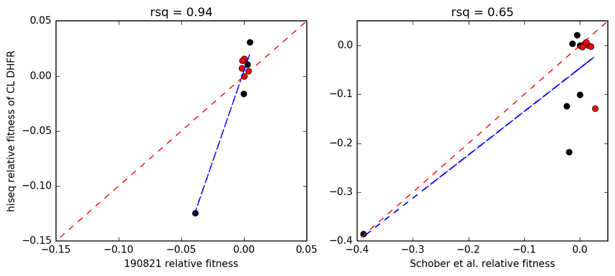

```python
# now correlate to CL fitness in this experiment!
cl_mutants = ['WT','M42F','L54I','W22H','D27N','L28F','L28Y','F31V','F31Y','G121V','T113V']


cl_mutants_exptIX = [dhfr_kinetics['dhfr'].index(m) for m in cl_mutants]
x_as = np.zeros(shape = (len(cl_mutants_exptIX),len(tyms)))
x_tn = np.zeros(shape = (len(cl_mutants_exptIX),len(tyms)))
y_hsq = np.zeros(shape = (len(cl_mutants_exptIX),len(tyms)))

aslx = []
asly = []
tnlx = []
tnly = []
plt.rcParams['figure.figsize'] = 10,4

tymsCol = ['k','r']

plt.figure()
for tsix, ts in enumerate(tyms):
    for hsq_mix, m in enumerate(cl_mutants):
        y_hsq[hsq_mix,tsix] = fitness_cl_mat[hsq_mix,tsix]

        if m in cl_190821_mut[tsix]:
            tn0821_mix = cl_190821_mut[tsix].index(m) #index of mutant in your dataset
            x_tn[hsq_mix,tsix] = cl_190821_fit[tsix][tn0821_mix]

            tnlx.append(x_tn[hsq_mix,tsix])
            tnly.append(y_hsq[hsq_mix,tsix])

            plt.subplot(1,2,1)
            plt.plot(x_tn[hsq_mix,tsix],y_hsq[hsq_mix,tsix],'o', color = tymsCol[tsix])

        if m in mutsASexpt:
            as_mix = mutsASexpt.index(m) #index of mutant in schober's data set
            x_as[hsq_mix,tsix] = ASrelGR50thyB2[tsix][as_mix]
            plt.subplot(1,2,2)
            plt.plot(x_as[hsq_mix,tsix],y_hsq[hsq_mix,tsix],'o',color = tymsCol[tsix])

            aslx.append(x_as[hsq_mix,tsix])
            asly.append(y_hsq[hsq_mix,tsix])

plt.subplot(1,2,1)
tnlx = np.array(tnlx)
tnly = np.array(tnly)
slope, intercept, r_value, p_value, std_err = stats.linregress(tnlx[~np.isnan(tnlx)],tnly[~np.isnan(tnlx)])
plt.plot(tnlx,tnlx*slope+intercept,'--')
plt.title('rsq = '+ str(round(r_value**2,2)))
plt.xlabel('190821 relative fitness')
plt.ylabel('hiseq relative fitness of CL DHFR')
plt.axis([-0.15,0.05,-0.15,0.05])
plt.plot([-1,1],[-1,1],'r--')

plt.subplot(1,2,2)
aslx = np.array(aslx)
asly = np.array(asly)
slope, intercept, r_value, p_value, std_err = stats.linregress(aslx[~np.isnan(asly)],asly[~np.isnan(asly)])
plt.title('rsq = '+ str(round(r_value**2,2)))
plt.plot(aslx,aslx*slope+intercept,'--b')
plt.xlabel('Schober et al. relative fitness')
plt.axis([-0.4,0.05,-0.4,0.05])
#plt.axis([-0.15,0.05,-0.15,0.05])
plt.plot([-1,1],[-1,1],'r--')

#print 'red line is y==x'
#print 'blue line is correlation'

plt.rcParams['figure.figsize'] = 5,4
```

Red: y=x

Blue: correlation

```python
#calculate relative frequencies and fitness for full library
relFreqFilter_mutNames = [],[]
relFreqFilter_timepoints = [],[]
relFreqFilter_ft = [],[]
relFreqFilter_fitsError = [],[]

listofFitnessEffects = [],[]

fitTally = 0

for tsix, ts in enumerate(tyms):
    for slix, slid in enumerate(sublibraries):
        for aaix, aa in enumerate(AA):
            for posix, pos in enumerate(aa_pos[slid]):
                mutName = wt_aa_sequence[slid][posix] + str(pos) + aa
                relFreqFilter_mutNames[tsix].append(mutName)

                mutMat = countPresent_mut_mat[slix,1:,tsix,posix,aaix]
                wtMat = countPresent_WT_mat[slix,1:,tsix]
                tp2fit, relFreq = relFreqFunc(mutMat,wtMat)
                if mutName[0] == mutName[-1]:
                    fitness_mut_mat[slix,tsix,posix,aaix] = 0
                                                            #shoving 0 in WT positions
                                                            # so that they show up as white pixels
                                                            # in the fitness heatmap
                    continue

                if 0 in tp2fit: #each mutant MUST BE PRESENT AT THE BEGINNING OF THE EXPERIMENT


                    relFreqFilter_timepoints[tsix].append(tp2fit)
                    relFreqFilter_ft[tsix].append(relFreq)

                    slope, intercept, r_value, p_value, std_err = stats.linregress(tp2fit,relFreq)
                    fitness_mut_mat[slix,tsix,posix,aaix] = slope
                    rsquared = r_value**2

                    if slope != np.log10(-1):
                        fitTally+=1

                    relFreqFilter_fitsError[tsix].append([slope,intercept,rsquared])
                    listofFitnessEffects[tsix].append(slope)
                else: #if they are not present shove in a NAN in the matrix
                    fitness_mut_mat[slix,tsix,posix,aaix] = np.log2(-1)
```

### Evaluating linear regression for random sets of mutants

The following cell randomly chooses mutants and plots their growth rate fits in both WT and R166Q TYMS backgrounds.

```
D79P wt fitness -0.003918497900413023 rsquared 0.12599989774069936
D79P r166q fitness 0.000310875063276397 rsquared 0.0031644063937690038
W30K wt fitness -0.22884171988897098 rsquared 0.9211512269091624
W30K r166q fitness 0.002935279937389914 rsquared 0.3599490199253558
F137E wt fitness nan rsquared nan
F137E r166q fitness -0.0005669837654558211 rsquared 0.006433145805780256
E118C wt fitness 0.0059264862725350205 rsquared 0.14737890719176444
E118C r166q fitness 0.018344287102246913 rsquared 0.39374994088550547
E129Q wt fitness 0.010243099149236769 rsquared 0.5226344055303815
E129Q r166q fitness -0.0014460979540505204 rsquared 0.028243086184142355
```

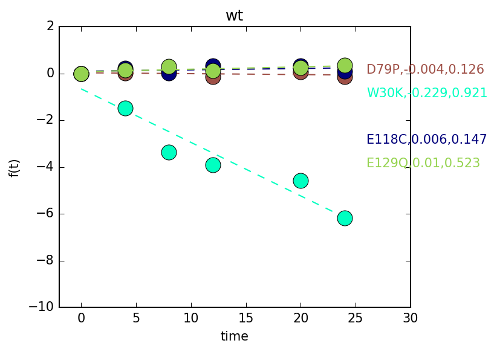

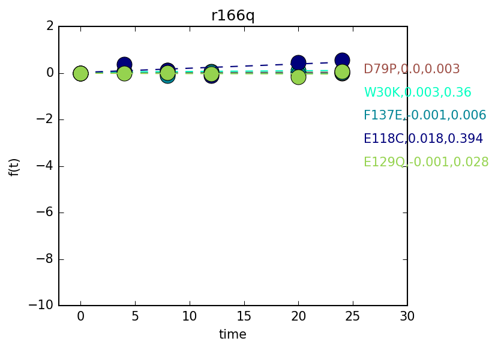

```python
plt.rcParams['figure.figsize'] = (5,4)

col = [8,9,10,11,12]
for x in range(0,5):
    randMut = np.random.randint(0,len(relFreqFilter_mutNames[0]))
    for tsix, ts in enumerate(tyms):
        plt.figure(tsix+1)
        plt.title(ts)
        plt.xlabel('time')
        plt.ylabel('f(t)')
        plt.xlim(-2,30)

        randMutName = relFreqFilter_mutNames[tsix][randMut]

        t = relFreqFilter_timepoints[tsix][randMut]
        ft = relFreqFilter_ft[tsix][randMut]
        plt.plot(t,ft,'o',color = prettyColors[col[x],:],markersize=12)

        m = relFreqFilter_fitsError[tsix][randMut][0]
        b = relFreqFilter_fitsError[tsix][randMut][1]
        rsq = relFreqFilter_fitsError[tsix][randMut][2]

        print (randMutName, ts, 'fitness',m, 'rsquared',rsq)

        if np.isnan(m):
            continue
        plt.plot(t,m*t+b,'--',color = prettyColors[col[x],:])
        mutlabel = randMutName+','+str(round(m,3))+','+str(round(rsq,3))
        plt.text(26,x*-1,mutlabel,color = prettyColors[col[x],:])
        plt.ylim(-10,2)
listofFitnessEffects = np.array(listofFitnessEffects) #need to make an array so that you can plot histogram
```

### What is the distribution of these fitness effects?

It is clear that with the prsence of R166Q TYMS that more mutants are not as deleterious as in the WT TYMS background. The frequency of mutants in the mode centered near zero increases and the tail of mutants with deleterious effects is flattened.

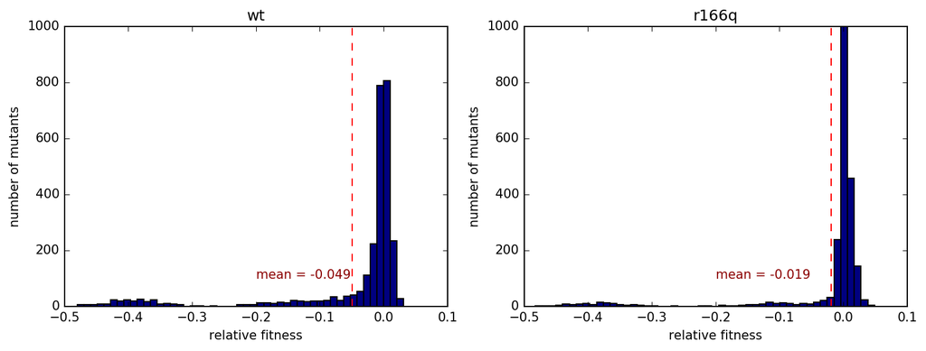

```python
# to pull out values in list that are not NAN, numpyarray[~np.isnan(list or numpyarray)]

plt.rcParams['figure.figsize'] = (12,4)
plt.figure()
for tsix, ts in enumerate(tyms):
    plt.subplot(1,2,tsix+1)
    plt.title(ts)
    plt.xlabel('relative fitness')
    plt.ylabel('number of mutants')
    fhist = np.array(listofFitnessEffects[tsix])[~np.isnan(listofFitnessEffects[tsix])]
    plt.hist(fhist,bins=50,color = 'navy')
    plt.ylim(0,1000)

    #calculate mean of distribution
    fm = np.mean(fhist)
    plt.plot([fm,fm],[0,2000],'r--')
    plt.text(-0.2,100,'mean = '+str(round(fm,3)),color = 'darkred')
```

```python
# now plot fitness heatmaps
def plot_heatmap(matrix,dhfr_wt_seq,colormap='viridis'):
##plots a heatmap of log10(matrix)
##matrix - the data

##x and y ticks spacing defaults to len of x and y axes of matrix
##x and y tick labels default to the indicies of x and y axes of the matrix. change it if you want to.

    yticks=np.arange(len(matrix[:,0]))
    ylabel = dhfr_wt_seq#np.arange(len(matrix[:,0]))

    xticks = np.arange(len(matrix[0,:]))
    xlabel= AA#np.arange(len(matrix[0,:]))

    plt.imshow((matrix), cmap = colormap, vmin = -0.5, vmax = 0.5, interpolation = 'nearest')

    #plt.colorbar(shrink = 0.3, orientation = 'vertical', pad = 0.01)
    plt.xticks(xticks+0.5,xlabel)
    plt.yticks(yticks+0.5,ylabel)
    plt.grid(color = 'k',linestyle = '-',linewidth = 1)

from matplotlib.colors import LinearSegmentedColormap
#these use HTML color coding to split range of colorbar from zero to 1.
colormap = cmap = LinearSegmentedColormap.from_list('mycmap', [(0.0, '#0000FF'), #primary red
                                                               (0.5, '#FFFFFF'), #white
                                                               (1,'#FF0000' )]) #primary blue
colormap.set_bad('navy',1.) #this sets all values that are -inf to grey (these are were not fitted!)
```

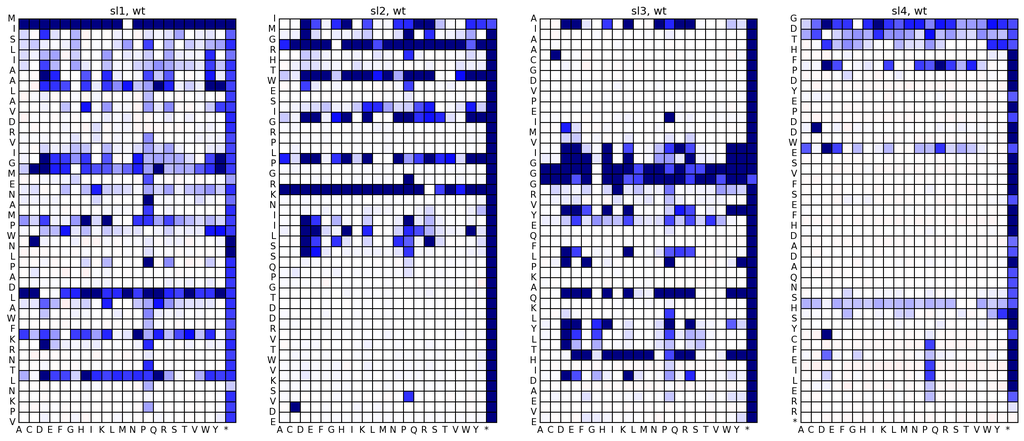

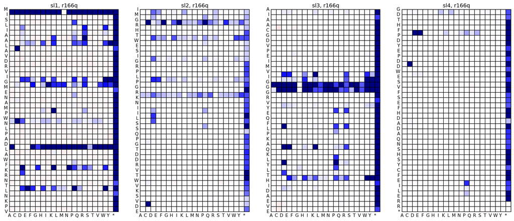

```python
#plot_heatmap(fitness_mut_mat[])
plt.rcParams['figure.figsize'] = (20,20)

for tsix, ts in enumerate(tyms):
    plt.figure()
    for slix, slid in enumerate(sublibraries):
        plt.subplot(1,4,slix+1)
        plt.title(slid+', '+ts)
        plt.imshow(fitness_mut_mat[slix,tsix,:,:],cmap = colormap, vmin = -0.5, vmax = 0.5, interpolation = 'nearest')

        yticks=np.arange(len(wt_aa_sequence[slid]))
        ylabel = wt_aa_sequence[slid]#np.arange(len(matrix[:,0]))

        xticks = np.arange(len(AA))
        xlabel= AA

        plt.xticks(xticks-0.5,xlabel)
        plt.yticks(yticks-0.5,ylabel)
        plt.xticks(xticks-0.5)
        plt.yticks(yticks-0.5)
        plt.grid(color = 'k',linestyle = '-',linewidth = 1)
```

In conclusion, R166Q TYMS broadly rescues growth rates of DHFR mutants in the WT TYMS background.

**What to do next?**

1. collect two more replicate measurements to determine error threshold for each DHFR mutant effect on bacterial growth rate
2. use average and error growth rates to test phenomenological model that relates DHFR and TYMS biochemical function to effect on growth rates.
3. calculate epistasis and map positions in DHFR enriched for buffering and aggravating epistasis on the strucutre of the enzyme.
4. determine if epistasis is correlated to evolutionary positional conservation

```python
# export fitness
fname = open('191124_fitness.txt','w')

for slix,sl in enumerate(sublibraries):
    for tsix, ts in enumerate(tyms):
        for ipos, pos in enumerate(aa_pos[sl]):
            for iaa, aa in enumerate(AA):
                mfit = fitness_mut_mat[slix,tsix,ipos,iaa]
                mutname = wt_aa_sequence[sl][ipos]+str(pos)+aa

                fname.write('%s\t%s\t%s\t%f\n' % (sl,ts,mutname,mfit))
fname.close()
```